# Introducción a R

# Sobre la visualización

R tienen funciones para hacer gráficas de manera rápida, por ejemplo, `hist` genera un histograma con el vector que le suministremos

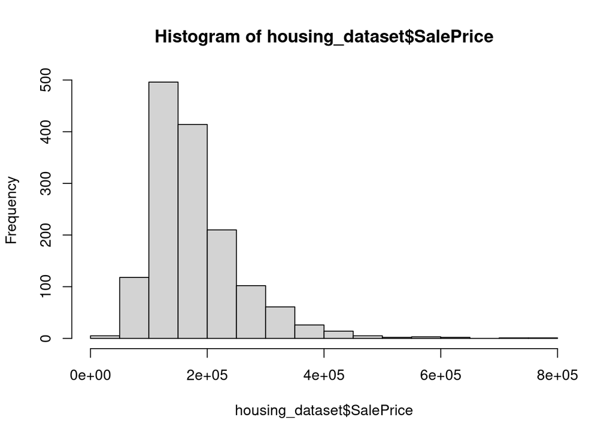

```r
hist(housing_dataset$SalePrice)
```

`plot` junto a `density` crea una gráfica de la densidad de los datos.

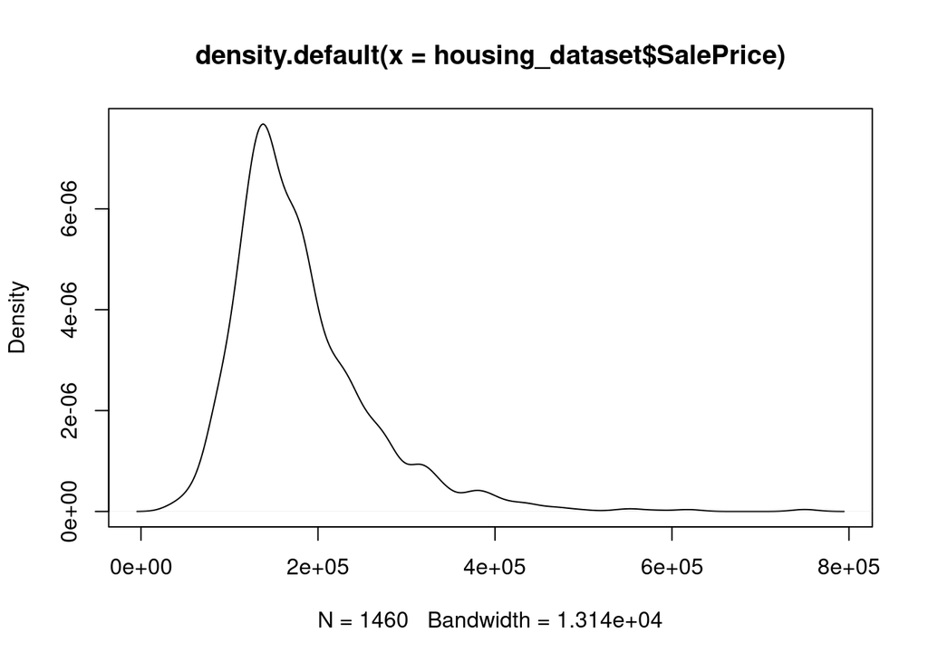

```r
plot(density(housing_dataset$SalePrice))
```

Para graficar la matriz de correlaciones ocuparemos la librería `corrplot`. Para poder empezar a usarla primero la instalamos y luego usamos la función `library` para cargarla.

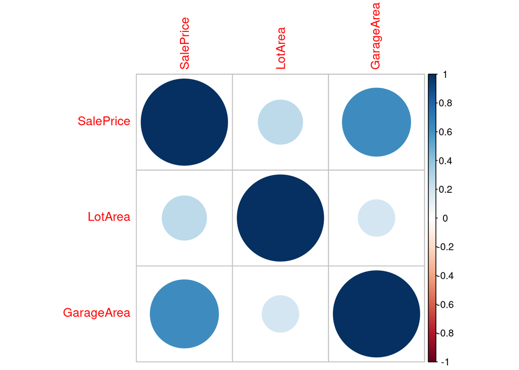

```r
install.packages("corrplot")
library(corrplot)
corrplot(cor(housing_dataset[,c('SalePrice', 'LotArea', 'GarageArea')]))
```

Podemos ver la relación entre las variables con gráficas de dispersión

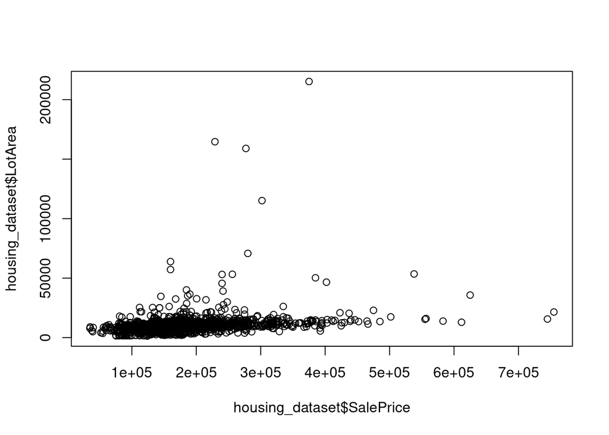

| **Ejercicio: Crear una gráfica de dispersión de GarageArea contra LotArea** |
| --- |

```r
plot(housing_dataset$SalePrice, housing_dataset$LotArea)
```

Ver distribución de los valores con diagramas de caja y bigotes

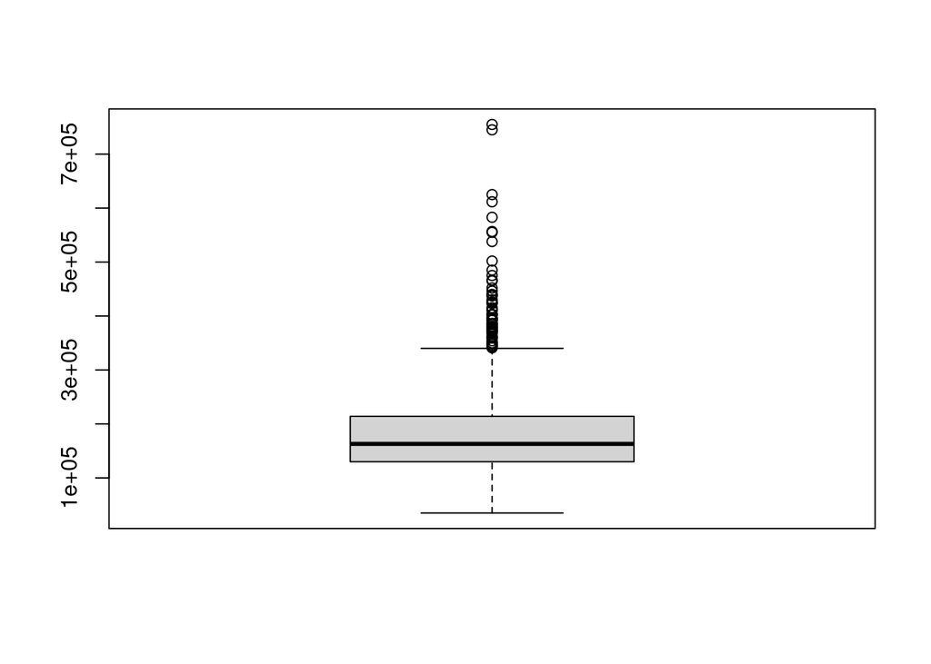

```r
boxplot(housing_dataset$SalePrice)
```

Diagrama de caja y bigotes de una variable en función de otra

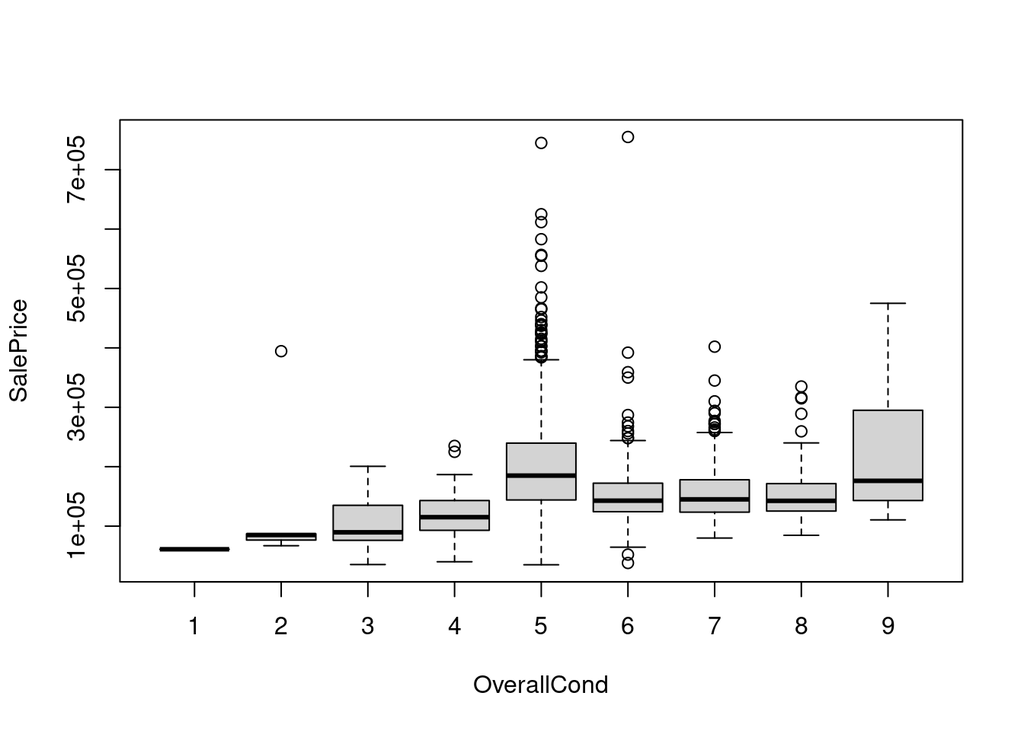

```r
boxplot(SalePrice ~ OverallCond, data = housing_dataset)
```

Visualizar dos (o más) gráficas en una sola con `par`

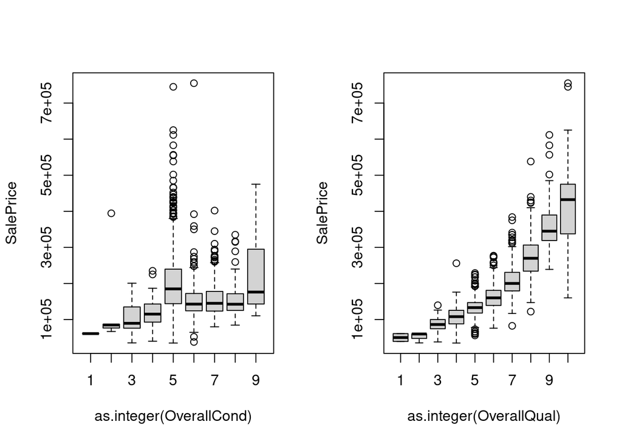

```r
par(mfrow = c(1, 2))

boxplot(SalePrice ~ as.integer(OverallCond), data = housing_dataset)
boxplot(SalePrice ~ as.integer(OverallQual), data = housing_dataset)
```

```r
par(mfrow = c(1, 1))
```

Todas las gráficas posibles entre dos variables en el dataset

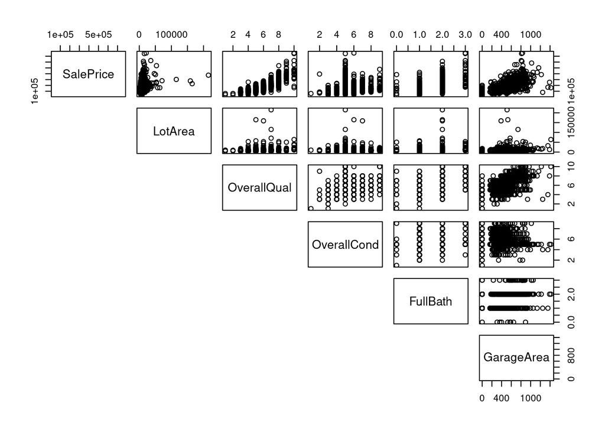

```r
housing_dataset <- lapply(housing_dataset, as.numeric)
pairs(housing_dataset, lower.panel = NULL)
```

Graficar sólo una parte de nuestros datos basándonos en un filtro.

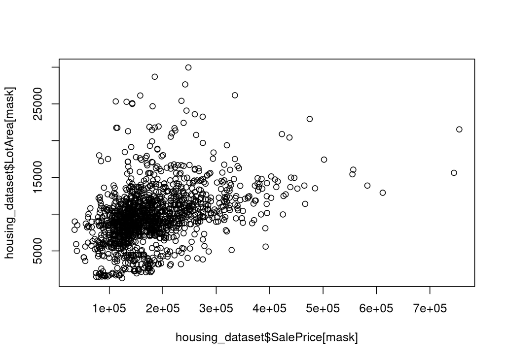

```r
mask = housing_dataset$LotArea < 30000
plot(housing_dataset$SalePrice[mask], housing_dataset$LotArea[mask])
```

Obtener conteos con `table`

```r
counts = table(housing_dataset$OverallQual)
counts
```

```
##
##   1   2   3   4   5   6   7   8   9  10
##   2   3  20 116 397 374 319 168  43  18
```

y luego visualizarlos con `barplot`

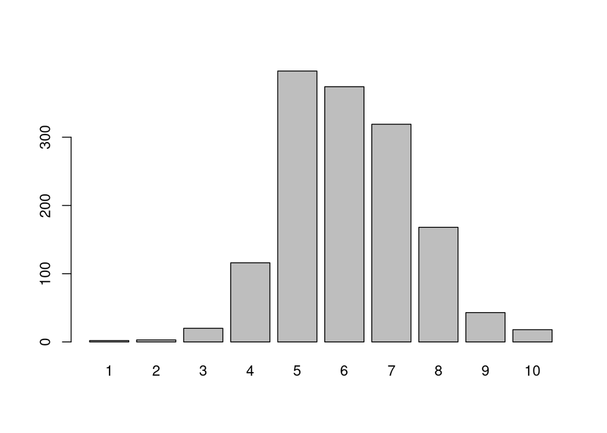

```r
barplot(counts)
```

## Agregando estilo a las gráficas

Se puede cambiar una variedad de parámetros visuales a las gráficas para cambiar su presentación (nota: la siguiente gráfica sólo es ilustrativa, se pueden hacer gráficas muy bonitas).

[figure not shown]

```r
barplot(counts, main = "Conteo de casas por calidad en general", xlab = "Calidad", ylab = "Conteo", col = "blue", border = "pink", density = 30, angle = 70)
```

El siguiente ejemplo muestra una gráfica de barras agrupada con dos variables.

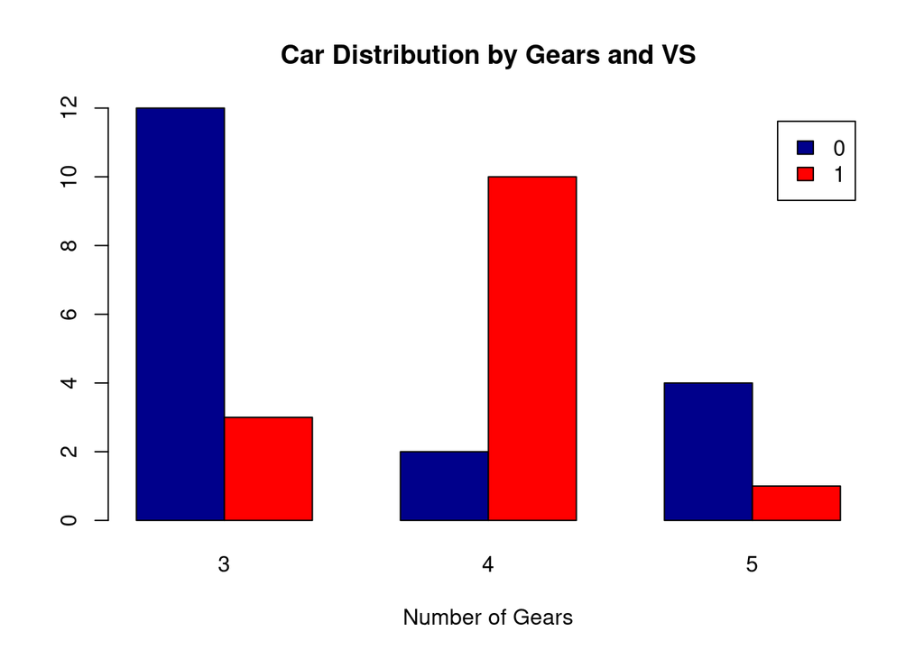

```r
# Grouped Bar Plot
# https://www.statmethods.net/graphs/bar.html
counts <- table(mtcars$vs, mtcars$gear)
barplot(counts, main="Car Distribution by Gears and VS",
  xlab="Number of Gears", col=c("darkblue","red"),
  legend = rownames(counts), beside=TRUE)
```

# Sobre tidyverse

[Tidyverse](https://www.tidyverse.org/) es un conjunto de librerías para la ciencia de datos. Facilita la manipulación y la visualización de los datos. (Personalmente me parece que se obtiene un código más leíble)

Para instalarlo basta con ejecutar la siguiente linea de código.

```r
# install.packages(tidyverse)
```

Se carga con la función `library`

```r
library(tidyverse)
```

Haremos las mismas acciones que se hicieron, pero con tidyverse.

```r
housing_data = read_csv('data/train.csv')
head(housing_data)
```

```
#> # A tibble: 6 × 81
#>      Id MSSubClass MSZoning LotFrontage LotArea Street Alley LotShape
#>   <dbl>      <dbl> <chr>          <dbl>   <dbl> <chr>  <chr> <chr>
#> 1     1         60 RL                65    8450 Pave   NA    Reg
#> 2     2         20 RL                80    9600 Pave   NA    Reg
#> 3     3         60 RL                68   11250 Pave   NA    IR1
#> 4     4         70 RL                60    9550 Pave   NA    IR1
#> 5     5         60 RL                84   14260 Pave   NA    IR1
#> 6     6         50 RL                85   14115 Pave   NA    IR1
#> # … with 73 more variables: LandContour <chr>, Utilities <chr>,
#> #   LotConfig <chr>, LandSlope <chr>, Neighborhood <chr>, Condition1 <chr>,
#> #   Condition2 <chr>, BldgType <chr>, HouseStyle <chr>, OverallQual <dbl>,
#> #   OverallCond <dbl>, YearBuilt <dbl>, YearRemodAdd <dbl>, RoofStyle <chr>,
#> #   RoofMatl <chr>, Exterior1st <chr>, Exterior2nd <chr>, MasVnrType <chr>,
#> #   MasVnrArea <dbl>, ExterQual <chr>, ExterCond <chr>, Foundation <chr>,
#> #   BsmtQual <chr>, BsmtCond <chr>, BsmtExposure <chr>, BsmtFinType1 <chr>, …
```

Obtenemos la media de los precios de venta.

```r
housing_data %>%
  summarise(mean(SalePrice), var(SalePrice))
```

```
#> # A tibble: 1 × 2
#>   `mean(SalePrice)` `var(SalePrice)`
#>               <dbl>            <dbl>
#> 1           180921.      6311111264.
```

Agrupando por una variable

```r
housing_data %>%
  group_by(OverallQual) %>%
  summarise(mean(SalePrice), var(SalePrice), n = n())
```

```
#> # A tibble: 10 × 4
#>    OverallQual `mean(SalePrice)` `var(SalePrice)`     n
#>          <dbl>             <dbl>            <dbl> <int>
#>  1           1            50150        235445000      2
#>  2           2            51770.       203182240.     3
#>  3           3            87474.       609525360.    20
#>  4           4           108421.       842276710.   116
#>  5           5           133523.       734807390.   397
#>  6           6           161603.      1302501304.   374
#>  7           7           207716.      1977248226.   319
#>  8           8           274736.      4083069709.   168
#>  9           9           367513.      6606141707.    43
#> 10          10           438588.     25531403153.    18
```

```r
housing_data %>%
  group_by(OverallQual) %>%
  summarise(`Precio Promedio` = mean(SalePrice/LotArea), Conteo = n())
```

```
#> # A tibble: 10 × 3
#>    OverallQual `Precio Promedio` Conteo
#>          <dbl>             <dbl>  <int>
#>  1           1              6.97      2
#>  2           2              6.96      3
#>  3           3             11.6      20
#>  4           4             16.1     116
#>  5           5             15.8     397
#>  6           6             21.1     374
#>  7           7             24.9     319
#>  8           8             28.2     168
#>  9           9             30.2      43
#> 10          10             28.1      18
```

| **Ejercicio: Obtener el promedio del precio por pie cuadrado agrupando por la calidad de la casa** |
| --- |

Podemos ocupar `ggplot2` para crear graficas. vamos a crear una gráfica de dispersión con `geom_point`.

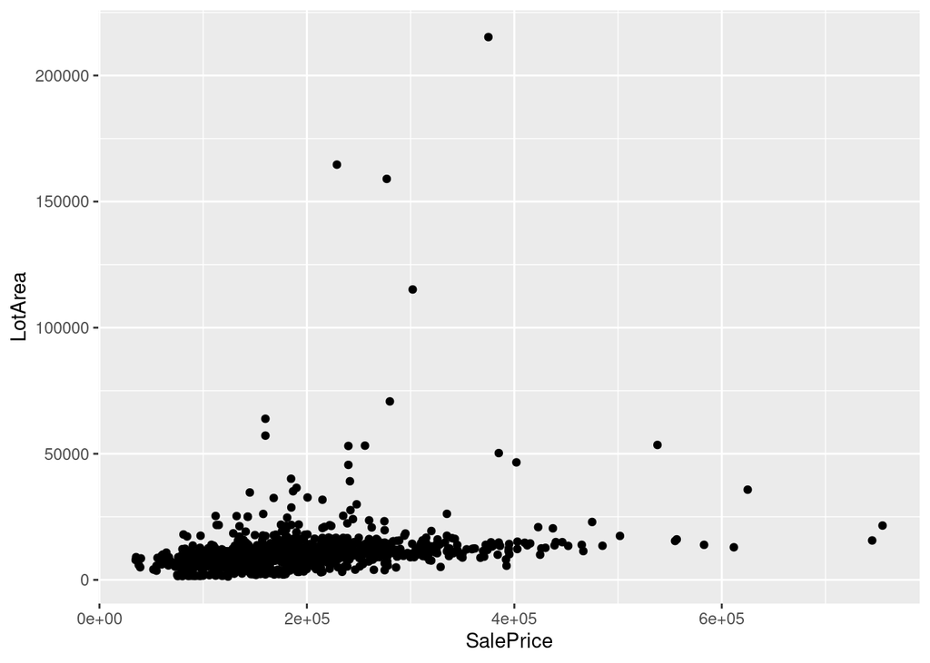

```r
housing_data %>%
  ggplot(aes(SalePrice, LotArea)) +
  geom_point()
```

Se pueden personalizar las gráficas de distintas maneras al igual que con R base. En la siguiente [liga](https://ggplot2-book.org/polishing.html) se muestran ejemplos más a detalle.

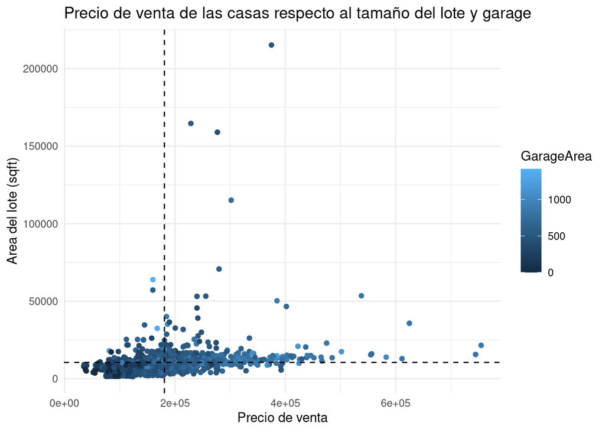

```r
mean_lot_area = mean(housing_data$LotArea)
mean_sale_price = mean(housing_data$SalePrice)

housing_data %>%
  ggplot(aes(SalePrice, LotArea, color = GarageArea)) +
  geom_point() +
  geom_hline(yintercept = mean_lot_area, linetype = 'dashed') +
  geom_vline(xintercept = mean_sale_price, linetype = 'dashed') +
  theme_minimal() +
  labs(
    title = 'Precio de venta de las casas respecto al tamaño del lote y garage',
    x = 'Precio de venta',
    y = 'Area del lote (sqft)'
  )
```

En el ejemplo anterior, se *mapeo* la variable `GarageArea` al color de los puntos. También podemos *mapear* variables al tamaño, la forma, la opacidad, etc.

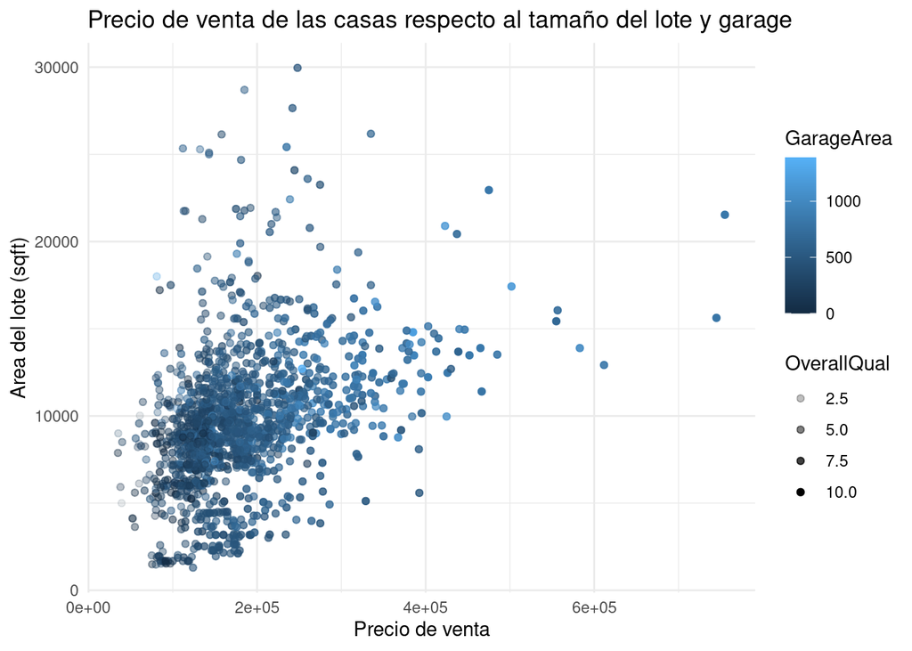

```r
housing_data %>%
  filter(LotArea < 30000) %>%
  ggplot(aes(SalePrice, LotArea, color = GarageArea, alpha = OverallQual)) +
  geom_point() +
  theme_minimal() +
  labs(
    title = 'Precio de venta de las casas respecto al tamaño del lote y garage',
    x = 'Precio de venta',
    y = 'Area del lote (sqft)'
  )
```

Ahora haremos una gráfica de la densidad del precio de venta, separando por la calidad de la casa.

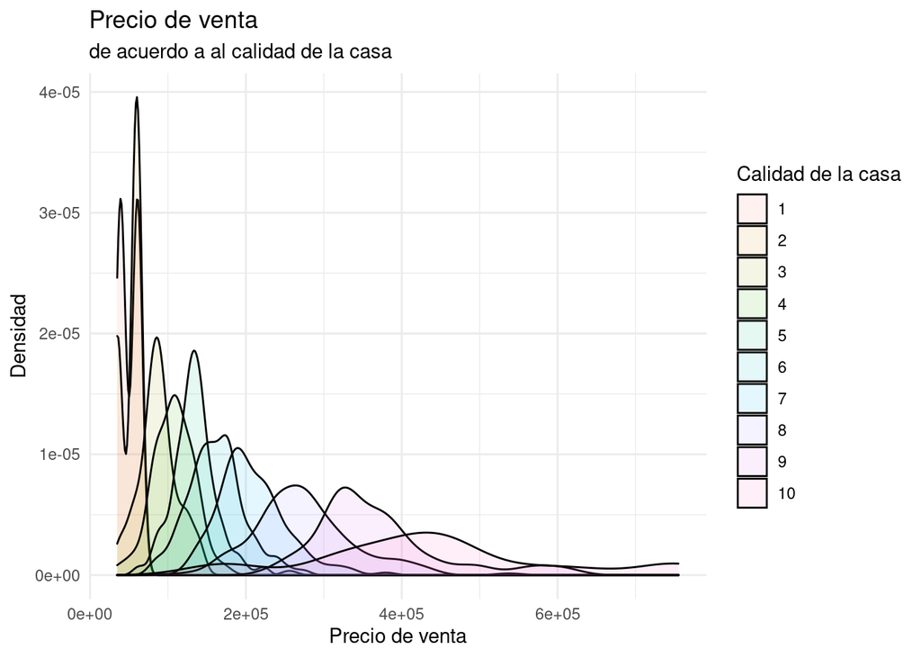

```r
housing_data %>%
  ggplot(aes(SalePrice, fill = as.factor(OverallQual))) +
  geom_density(alpha = .1) +
  theme_minimal() +
  labs(
    fill = "Calidad de la casa",
    title = 'Precio de venta',
    subtitle= 'de acuerdo a al calidad de la casa',
    x = "Precio de venta",
    y = 'Densidad'
  )
```

Podemos separar la gráfica con `facetas` de la siguiente manera.

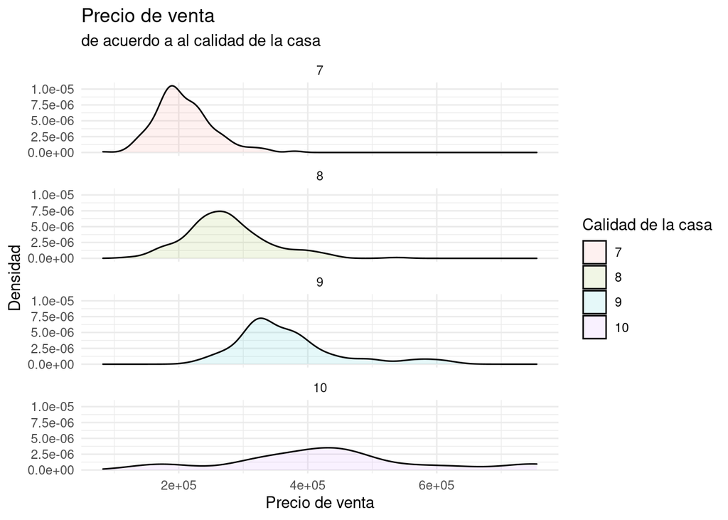

[output not shown]

```r
housing_data %>%
  filter(OverallQual %in% c(7, 8, 9, 10)) %>%
  ggplot(aes(SalePrice, fill = as.factor(OverallQual))) +
  geom_density(alpha = .1) +
  facet_wrap(~OverallQual, ncol = 1) +
  theme_minimal() +
  labs(
    fill = "Calidad de la casa",
    title = 'Precio de venta',
    subtitle= 'de acuerdo a al calidad de la casa',
    x = "Precio de venta",
    y = 'Densidad'
  )
```

# Ligas interesantes

- [The R Book](https://www.cs.upc.edu/~robert/teaching/estadistica/TheRBook.pdf): Libro que cubre todo lo que hay que saber sobre R base.
- [R for Data Science](https://r4ds.had.co.nz/): Libro que ocupa tidyverse para la ciencia de datos con R.